# edX Intro to Bioconductor section 2: Structure and management of genome-scale data with Bioconductor

Josh Cook

2018-06-06

# Structures tailored to microarray experiments

## ExpressionSet: self-describing container for microarray studies

```r
library(GSE5859Subset)
data(GSE5859Subset)
ls()
```

```
[1] "geneAnnotation" "geneExpression" "plotGRanges"    "plotRanges"     "sampleInfo"
```

```r
head(geneAnnotation)
```

```
     PROBEID  CHR     CHRLOC SYMBOL
1  1007_s_at chr6   30852327   DDR1
30   1053_at chr7  -73645832   RFC2
31    117_at chr1  161494036  HSPA6
32    121_at chr2 -113973574   PAX8
33 1255_g_at chr6   42123144 GUCA1A
34   1294_at chr3  -49842638   UBA7
```

Construct an expression set:

```r
rownames(geneAnnotation) <- geneAnnotation$PROBEID
es5859 <- ExpressionSet(assayData = geneExpression)
pData(es5859) <- sampleInfo
fData(es5859) <- geneAnnotation
es5859
```

```
ExpressionSet (storageMode: lockedEnvironment)
assayData: 8793 features, 24 samples
  element names: exprs
protocolData: none
phenoData
  sampleNames: 107 122 ... 159 (24 total)
  varLabels: ethnicity date filename group
  varMetadata: labelDescription
featureData
  featureNames: 1007_s_at 1053_at ... AFFX-r2-P1-cre-5_at (8793 total)
  fvarLabels: PROBEID CHR CHRLOC SYMBOL
  fvarMetadata: labelDescription
experimentData: use 'experimentData(object)'
Annotation:
```

Add annotations of a paper that adhere to MIAME format.

```r
library(annotate)
mi <- pmid2MIAME("29295815")
```

```
Read 391 items
```

```r
mi
```

```
Experiment data
  Experimenter name: Cook JH
  Laboratory: NA
  Contact information:
  Title: Toxoplasma gondiidisrupts β1 integrin signaling and focal adhesion formation during monocyte hypermotility.
  URL:
  PMIDs: 29295815

  Abstract: A 225 word abstract is available. Use 'abstract' method.
```

Assign as metadata to the ExpressionSet:

```r
experimentData(es5859) <- mi
es5859
```

```
ExpressionSet (storageMode: lockedEnvironment)
assayData: 8793 features, 24 samples
  element names: exprs
protocolData: none
phenoData
  sampleNames: 107 122 ... 159 (24 total)
  varLabels: ethnicity date filename group
  varMetadata: labelDescription
featureData
  featureNames: 1007_s_at 1053_at ... AFFX-r2-P1-cre-5_at (8793 total)
  fvarLabels: PROBEID CHR CHRLOC SYMBOL
  fvarMetadata: labelDescription
experimentData: use 'experimentData(object)'
  pubMedIds: 29295815
Annotation:
```

## The GEOquery package: ExpressionSets from NCBI’s repository

GEO = Gene Expression Omnibus  
Can use `GEOmetadb` to search through all the metadata available in GEO (*NOTE*: it will download a large file containing all of the data!).  
Use the library `GEOquery` to get ExpressionSet from publications.

```r
library(GEOquery)
glioMA = getGEO("GSE78703")
glioMA
```

```
$GSE78703_series_matrix.txt.gz
ExpressionSet (storageMode: lockedEnvironment)
assayData: 49395 features, 12 samples
  element names: exprs
protocolData: none
phenoData
  sampleNames: GSM2072905 GSM2072906 ... GSM2072916 (12 total)
  varLabels: title geo_accession ... treated with:ch1 (35 total)
  varMetadata: labelDescription
featureData
  featureNames: 11715100_at 11715101_s_at ... AFFX-TrpnX-M_at (49395 total)
  fvarLabels: ID GeneChip Array ... SPOT_ID (24 total)
  fvarMetadata: Column Description labelDescription
experimentData: use 'experimentData(object)'
Annotation: GPL15207
```

Access the European version of GEO, **EMBL-EBI**, using `ArrayExpress`. Query using `queryAE()` (does *not* download a huge file of the metadata).

```r
library(ArrayExpress)
sets = queryAE(keywords = "glioblastoma", species = "homo+sapiens")
```

[output not shown]

```r
dim(sets)
```

```
[1] 533   8
```

To interrogate 533 entries, can use the `DT` library to create an HTML file with a pretty table.

```r
library(DT)
datatable(sets)
# open the file in R Viewer tab and then export as "Save as Web Page..."
```

## ExpressionSet Assessment

```r
library(Biobase)
library(genefu)
data(nkis)
dim(demo.nkis)
```

```
[1] 150  19
```

```r
head(demo.nkis)[,1:8]
```

```
        dataset series  id er grade node size age
NKI_123     NKI   NKI2 123  1     3    0  2.0  48
NKI_327     NKI   NKI2 327  1     2    1  2.0  49
NKI_291     NKI   NKI2 291  1     2    1  1.2  39
NKI_370     NKI   NKI2 370  1     1    1  1.8  51
NKI_178     NKI   NKI2 178  1     2    1  3.0  48
NKI_176     NKI   NKI2 176  1     2    1  5.0  46
```

```r
# purposefully errors
nkes = ExpressionSet(data.nkis, phenoData=AnnotatedDataFrame(demo.nkis),
                     featureData=AnnotatedDataFrame(annot.nkis))
```

```r
library(GEOquery)
# retrieve the LSC data from GEO
lstem = getGEO("GSE3725")
```

```
Found 1 file(s)
GSE3725_series_matrix.txt.gz
==================================================

File stored at:
/var/folders/r4/qpcdgl_14hbd412snp1jnv300000gn/T//RtmpQOrIyw/GPL339.soft
```

```r
class(lstem)
```

```
[1] "list"
```

```r
lstem = lstem[[1]]
```

```r
dim(lstem)
```

```
Features  Samples
   22690       28
```

4. In this case, the sample characteristic of interest is the type of cell on which expression measures were taken. This can be found using the ‘title’ field of the pData(lstem). In other words,

```r
pData(lstem)$title
```

```
 [1] GMP expressing GFPrep1                     GMP expressing GFPrep2
 [3] GMP expressing GFPrep3                     GMP expressing MLL_AF9rep1
 [5] GMP expressing MLL_AF9rep2                 GMP expressing MLL_AF9rep3
 [7] Lin-, sca+, kit+ (HSC enriched)rep1        Lin-, sca+, kit+ (HSC enriched)rep2
 [9] Lin-, sca+, kit+ (HSC enriched)rep3        Lin-, sca+, kit+ (HSC enriched)rep4
[11] Lin-, sca+, kit+ (HSC enriched)rep5        Lin-, sca-, kit+, FCR+, CD34low(CMP)rep1
[13] Lin-, sca-, kit+, FCR+, CD34low(CMP)rep2   Lin-, sca-, kit+, FCR+, CD34low(CMP)rep3
[15] Lin-, sca-, kit+, FCR+, CD34low(CMP)rep4   Lin-, sca-, kit+, FCR+, CD34high(GMP)rep1
[17] Lin-, sca-, kit+, FCR+, CD34high(GMP)rep2  Lin-, sca-, kit+, FCR+, CD34high(GMP)rep3
[19] Lin-, sca-, kit+, FCR+, CD34high(GMP)rep4  Lin-, sca-, kit+, FCR-, CD34- (MEP)rep1
[21] Lin-, sca-, kit+, FCR-, CD34- (MEP)rep2    Lin-, sca-, kit+, FCR-, CD34- (MEP)rep3
[23] Lin-, sca-, kit+, FCR+, CD34+ (L-GMP)rep1  Lin-, sca-, kit+, FCR+, CD34+ (L-GMP)rep2
[25] Lin-, sca-, kit+, FCR+, CD34+ (L-GMP)rep3  Lin-, sca-, kit+, FCR+, CD34+ (L-GMP) rep4
[27] Lin-, sca-, kit+, FCR+, CD34+ (L-GMP) rep5 Lin-, sca-, kit+, FCR+, CD34+ (L-GMP) rep6
28 Levels: GMP expressing GFPrep1 GMP expressing GFPrep2 ... Lin-, sca+, kit+ (HSC enriched)rep5
```

generates a listing of the cell type descriptions. Let’s ignore the first 6 samples:

```r
lstem = lstem[, -c(1:6)]
```

How many samples are of type L-GMP?

```r
View(pData(lstem)$title)
```

6. We’ll conclude this problem set by producing a heatmap that compares the cell types in a useful way. The data in GEO are apparently not normalized. We will use a very crude approach to achieve constant median on the log scale, after recoding (rare) negative values to zero and then adding 1 to all values.

```r
## perform an elementary normalization
ee = exprs(lstem)
ee[ee<0] = 0
eee = log(ee+1)
## boxplot(data.frame(eee))
meds = apply(eee,2,median)
tt = t(t(eee)-meds)
## boxplot(data.frame(tt))
## assign the normalized values to ExpressionSet
exprs(lstem) = tt
```

Now we will modify the feature names to be gene symbols instead of array probe names.

```r
# simplify downstream labeling with gene symbol
featureNames(lstem) = make.names(fData(lstem)$"Gene Symbol", unique=TRUE)
```

The following code is somewhat complex, but it simplifies labeling of cell types by stripping away details of marker configurations.

```r
  # reformat the naming of cell types
ct = pData(lstem)[,1]
ct = as.character(ct)
cct = gsub(".*(\\(.*\\)).*", "\\1", ct)
cct = make.unique(cct)
cct = gsub(" enriched", "", cct)
# use the cell types as sample names
sampleNames(lstem) = cct
```

Four genes identified in the stemness signature are given in a vector below. We will use these for a small-scale heatmap.

```r
  # select some members of the stem cell signature
inds = which(fData(lstem)$"Gene Symbol" %in% c("Stat1", "Col4a1", "Hoxa9", "Itgb5"))
```

Finally we can produce the heatmap.

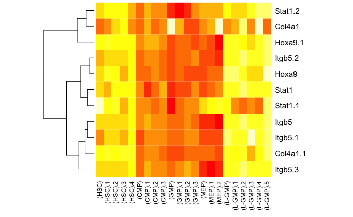

```r
# obtain a simple heatmap
heatmap(exprs(lstem[inds,]), Colv=NA)
```

What’s the total number of probes interrogating the four genes of interest?

```r
length(inds)
```

```
[1] 11
```

# Interlude: IRanges and GRanges preparatory to SummarizedExperiment

## Interval ranges: IRanges

```r
library(IRanges)
ir <- IRanges(5,10)
ir
```

```
IRanges object with 1 range and 0 metadata columns:
          start       end     width
      <integer> <integer> <integer>
  [1]         5        10         6
```

IRanges methods are roughly divided into intra- and inter-range methods. They are all focused around controlling ranges of integers. Some of the common ones are `shift`, `narrow`, `flank`, `*`, `+`, `-`, `range`, `reduce`, `gaps`, `disjoin`.

## IRanges Assessment

1. Load the IRanges package. Define an integer range starting at 101 and ending at 200. If we use the operation *2, this will zoom in, giving us a range with half the width. What is the starting point of the resulting range?

```r
(ir <- IRanges(101, 200))
```

```
IRanges object with 1 range and 0 metadata columns:
          start       end     width
      <integer> <integer> <integer>
  [1]       101       200       100
```

```r
(ir <- ir * 2)
```

```
IRanges object with 1 range and 0 metadata columns:
          start       end     width
      <integer> <integer> <integer>
  [1]       126       175        50
```

```r
start(ir)
```

```
[1] 126
```

2. Define an integer range starting at 101 and ending at 200. If we use the operation narrow(x, start=20), what is the new starting point of the range?

```r
(ir <- IRanges(101,200))
```

```
IRanges object with 1 range and 0 metadata columns:
          start       end     width
      <integer> <integer> <integer>
  [1]       101       200       100
```

```r
(ir <- narrow(ir, start=20))
```

```
IRanges object with 1 range and 0 metadata columns:
          start       end     width
      <integer> <integer> <integer>
  [1]       120       200        81
```

3. Define an integer range starting at 101 and ending at 200. If we use the operation +25, what is the width of the resulting range?

```r
(ir <- IRanges(101, 200) + 25)
```

```
IRanges object with 1 range and 0 metadata columns:
          start       end     width
      <integer> <integer> <integer>
  [1]        76       225       150
```

4. Define an IRanges with starts at 1,11,21 and ends at 3,15,27. width() gives the widths for each range. What is the sum of the widths of all the ranges?

```r
(ir <- IRanges(start=c(1,11,21), end=c(3,15,27)))
```

```
IRanges object with 3 ranges and 0 metadata columns:
          start       end     width
      <integer> <integer> <integer>
  [1]         1         3         3
  [2]        11        15         5
  [3]        21        27         7
```

```r
width(ir) %>% sum
```

```
[1] 15
```

5. Define an IRanges object, x, with the following set of ranges:

```r
Starts <- c(101,106,201,211,221,301,306,311,351,361,401,411,501)
Ends <- c(150,160,210,270,225,310,310,330,390,380,415,470,510)
ir <- IRanges(start = Starts, end = Ends)
```

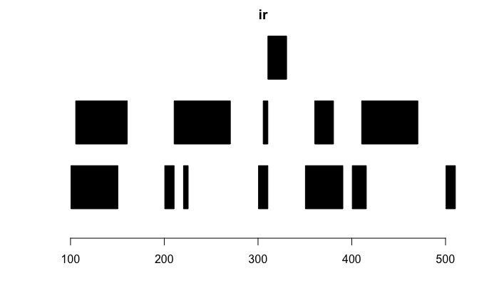

```r
plotRanges(ir)
```

What is the total width from 101 to 510 which is not covered by ranges in x?

```r
gaps(ir) %>% width %>% sum
```

```
[1] 130
```

6. How many disjoint ranges are contained within the ranges in `ir` from the previous question? By disjoint ranges, we mean the following: for two ranges [1,10] and [6,15], there are three disjoint ranges contained within: [1,5], [6,10], and [11,15].

```r
length(disjoin(ir))
```

```
[1] 17
```

7. An intra-range function we didn’t show in the video is resize(). Set up a grid of 2 stacked plots:

```r
par(mfrow=c(2,1))
```

Now use `plotRanges()` to plot the original `ir`, and `resize(ir,1)`. You will have to set the xlim to make sure that the plots line up vertically. You can use `plotRanges(ir, xlim=c(0,600))` for example.  
What is the best description for the operation `resize(ir,1)`?

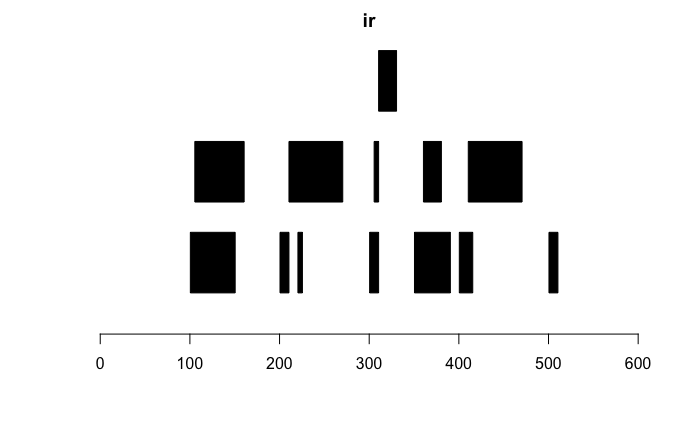

```r
plotRanges(ir, xlim=c(0,600))
```

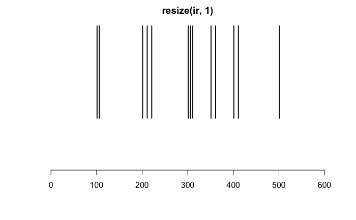

```r
plotRanges(resize(ir,1), xlim=c(0,600))
```

## Genomic ranges: GRanges

```r
library(GenomicRanges)
gr <- GRanges(seqnames = "chrZ",
              IRanges(start = c(5,10), end = c(35,45)),
              strand = "+",
              seqlengths = c(chrZ=100L))
gr
```

```
GRanges object with 2 ranges and 0 metadata columns:
      seqnames    ranges strand
         <Rle> <IRanges>  <Rle>
  [1]     chrZ      5-35      +
  [2]     chrZ     10-45      +
  -------
  seqinfo: 1 sequence from an unspecified genome
```

Can move the range:

```r
shift(gr, 10)
```

```
GRanges object with 2 ranges and 0 metadata columns:
      seqnames    ranges strand
         <Rle> <IRanges>  <Rle>
  [1]     chrZ     15-45      +
  [2]     chrZ     20-55      +
  -------
  seqinfo: 1 sequence from an unspecified genome
```

If you shift off the chromosome `chrZ`:

```r
shift(gr, 80)
```

[output not shown]

```
GRanges object with 2 ranges and 0 metadata columns:
      seqnames    ranges strand
         <Rle> <IRanges>  <Rle>
  [1]     chrZ    85-115      +
  [2]     chrZ    90-125      +
  -------
  seqinfo: 1 sequence from an unspecified genome
```

Can use trim to stop at the end of the chromosome:

```r
trim(shift(gr, 80))
```

[output not shown]

```
GRanges object with 2 ranges and 0 metadata columns:
      seqnames    ranges strand
         <Rle> <IRanges>  <Rle>
  [1]     chrZ    85-100      +
  [2]     chrZ    90-100      +
  -------
  seqinfo: 1 sequence from an unspecified genome
```

Access the metadata columns:

```r
# they are currently empty
mcols(gr)
```

```
DataFrame with 2 rows and 0 columns
```

Add metadata:

```r
mcols(gr)$value <- c(-1,4)
mcols(gr)$anothercol <- c("a","b")
gr
```

```
GRanges object with 2 ranges and 2 metadata columns:
      seqnames    ranges strand |     value  anothercol
         <Rle> <IRanges>  <Rle> | <numeric> <character>
  [1]     chrZ      5-35      + |        -1           a
  [2]     chrZ     10-45      + |         4           b
  -------
  seqinfo: 1 sequence from an unspecified genome
```

Can make a list of GRange objects. Removing the two columns of metadata from `gr` is not required; the same columns would be applied to `gr2` within `grl` and be populated with `NA`.

```r
mcols(gr)$value <- mcols(gr)$anothercol <- NULL
gr2 <- GRanges("chrZ", IRanges(11:13, 51:53))
grl <- GRangesList(gr, gr2)
```

An example use of `GRangesList()` is to hold the exons for transcripts.

## findOverlaps and %over%

```r
(gr1 <- GRanges("chrZ",IRanges(c(1,11,21,31,41),width=5),strand="*"))
```

```
GRanges object with 5 ranges and 0 metadata columns:
      seqnames    ranges strand
         <Rle> <IRanges>  <Rle>
  [1]     chrZ       1-5      *
  [2]     chrZ     11-15      *
  [3]     chrZ     21-25      *
  [4]     chrZ     31-35      *
  [5]     chrZ     41-45      *
  -------
  seqinfo: 1 sequence from an unspecified genome; no seqlengths
```

```r
(gr2 <- GRanges("chrZ",IRanges(c(19,33),c(38,35)),strand="*"))
```

```
GRanges object with 2 ranges and 0 metadata columns:
      seqnames    ranges strand
         <Rle> <IRanges>  <Rle>
  [1]     chrZ     19-38      *
  [2]     chrZ     33-35      *
  -------
  seqinfo: 1 sequence from an unspecified genome; no seqlengths
```

`findOverlaps` returns a `Hits` object which contains the information about which ranges in the `query` (the first argument) overlapped which ranges in the `subject` (the second argument). *There are many options for specifying what kind of overlaps should be counted.*

```r
(fo <- findOverlaps(gr1, gr2))
```

```
Hits object with 3 hits and 0 metadata columns:
      queryHits subjectHits
      <integer>   <integer>
  [1]         3           1
  [2]         4           1
  [3]         4           2
  -------
  queryLength: 5 / subjectLength: 2
```

Can get inidividual data using the following functions:

```r
queryHits(fo)
```

```
[1] 3 4 4
```

```r
subjectHits(fo)
```

```
[1] 1 1 2
```

Can also use `%over%` to get a logical vector of overlaps used for subsetting the query to get the sequeces that had overlaps.

```r
gr1[gr1 %over% gr2]
```

```
GRanges object with 2 ranges and 0 metadata columns:
      seqnames    ranges strand
         <Rle> <IRanges>  <Rle>
  [1]     chrZ     21-25      *
  [2]     chrZ     31-35      *
  -------
  seqinfo: 1 sequence from an unspecified genome; no seqlengths
```

Can ingore a strand using the `ingore.strand` argument:

```r
gr1 <- GRanges("chrZ",IRanges(1,10),strand="+")
gr2 <- GRanges("chrZ",IRanges(1,10),strand="-")
gr1 %over% gr2
```

```
[1] FALSE
```

```r
(r <- Rle(c(1,1,1,0,0,-2,-2,-2,rep(-1,20))))
```

```
numeric-Rle of length 28 with 4 runs
  Lengths:  3  2  3 20
  Values :  1  0 -2 -1
```

```r
str(r)
```

```
Formal class 'Rle' [package "S4Vectors"] with 4 slots
  ..@ values         : num [1:4] 1 0 -2 -1
  ..@ lengths        : int [1:4] 3 2 3 20
  ..@ elementMetadata: NULL
  ..@ metadata       : list()
```

```r
as.numeric(r)
```

```
 [1]  1  1  1  0  0 -2 -2 -2 -1 -1 -1 -1 -1 -1 -1 -1 -1 -1 -1 -1 -1 -1 -1 -1 -1 -1 -1 -1
```

A `Views` object (in `IRanges`) can be thought of as “windows” looking into a sequence.

```r
(v <- Views(r, start=c(4,2), end=c(7,6)))
```

```
Views on a 28-length Rle subject

views:
    start end width
[1]     4   7     4 [ 0  0 -2 -2]
[2]     2   6     5 [ 1  1  0  0 -2]
```

Note that the internal structure of the `Views` object is just the original object, and the `IRanges` which specify the windows. The great benefit of `Views` is when the original object is not stored in memory, in which case the `Views` object is a lightweight class which helps us reference subsequences, without having to load the entire sequence into memory.

```r
str(v)
```

```
Formal class 'RleViews' [package "IRanges"] with 5 slots
  ..@ subject        :Formal class 'Rle' [package "S4Vectors"] with 4 slots
  .. .. ..@ values         : num [1:4] 1 0 -2 -1
  .. .. ..@ lengths        : int [1:4] 3 2 3 20
  .. .. ..@ elementMetadata: NULL
  .. .. ..@ metadata       : list()
  ..@ ranges         :Formal class 'IRanges' [package "IRanges"] with 6 slots
  .. .. ..@ start          : int [1:2] 4 2
  .. .. ..@ width          : int [1:2] 4 5
  .. .. ..@ NAMES          : NULL
  .. .. ..@ elementType    : chr "ANY"
  .. .. ..@ elementMetadata: NULL
  .. .. ..@ metadata       : list()
  ..@ elementType    : chr "ANY"
  ..@ elementMetadata: NULL
  ..@ metadata       : list()
```

## GRanges Assessment

The GRanges object in the GenomicRanges package extends the concept of interval ranges in two major ways. The ranges are now also identified by:

1. the chromosome we are referring to (in Bioconductor, this is called “seqnames”)
2. the strand of the DNA we are referring to (“+” or “-”). No strand is labelled with a star, “*“.

```r
x = GRanges("chr1", IRanges(c(1,101),c(50,150)), strand=c("+","-"))
```

Plot `x` and `resize(x,1)`:

```r
par(2,1)
```

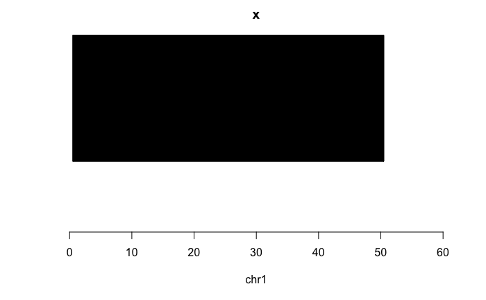

```r
plotGRanges(x)
```

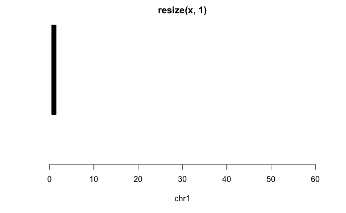

```r
plotGRanges(resize(x,1))
```

2. Suppose we have two different sets of ranges, which overlap somewhat but not entirely. This is the case for many genes, in which there are different versions of transcripts, also called isoforms. The different transcripts consist of exons which end up in the final mRNA molecule, and a number of transcripts can share exons or have exons which are overlapping but not identical ranges. We’ll start with a toy example, and learn how to load real genes later:

```r
x = GRanges("chr1", IRanges(c(101,201,401,501),c(150,250,450,550)), strand="+")
y = GRanges("chr1", IRanges(c(101,221,301,401,541),c(150,250,350,470,550)), strand="+")
```

[figure not shown]

```r
par(mfrow=c(2,1))
plotGRanges(x)
plotGRanges(y)
```

If we want to keep the information about which set the ranges belong to, we could combine the two GRanges into a GRangesList: `GRangesList(x,y)`. However, if we want to combine them into a single GRanges, we can use c(): `c(x,y)`. Find the total width which is covered by ranges in both x and y. Hint: use c(), disjoin() and %over%.

```r
disjoined = disjoin(c(x,y))
in.both = disjoined %over% x & disjoined %over% y
sum(width(disjoined[ in.both ]))
```

```
[1] 140
```

3. What is the total width which is in x or y but not in both?

```r
xyonly <- disjoined[!in.both]
sum(width(xyonly))
```

```
[1] 130
```

4. Define a new genomic range, `z`, which covers `range(ranges(x))` but has the opposite strand. What is the number of ranges in `x` which overlap `z` according to the %over% command?

```r
z <- GRanges("chr1", IRanges(ranges(x)), strand = "-")
sum(z %over% x)
```

```
[1] 0
```

**Note:** The %over% command is specific to strand. If we want to find the ranges regardless of strand, we need to assign a strand of `*`.

## Operating on GRanges

Let’s define a new `IRanges` object:

```r
ir <- IRanges(c(3, 8, 14, 15, 19, 34, 40),
              width = c(12, 6, 6, 15, 6, 2, 7))
```

Using `reduce`:

[figure not shown]

```r
par(mfrow=c(2,1), mar=c(4,2,2,2))
plotRanges(ir)
plotRanges(reduce(ir))
```

Compared to `disjoin`:

[figure not shown]

```r
par(mfrow=c(2,1), mar=c(4,2,2,2))
plotRanges(ir)
plotRanges(disjoin(ir))
```

The `reduce` function is good for reducing completexity.  
Using the `gaps` function to find missing regions (eg. find the introns when given exons).

[figure not shown]

```r
par(mfrow=c(2,1), mar=c(4,2,2,2))
plotRanges(ir, xlim=c(0, 60))
plotRanges(gaps(ir), xlim=c(0,60))
```

```r
library(GenomicRanges)
gir <- GRanges(seqnames="chr1", ir)
gir
```

```
GRanges object with 7 ranges and 0 metadata columns:
      seqnames    ranges strand
         <Rle> <IRanges>  <Rle>
  [1]     chr1      3-14      *
  [2]     chr1      8-13      *
  [3]     chr1     14-19      *
  [4]     chr1     15-29      *
  [5]     chr1     19-24      *
  [6]     chr1     34-35      *
  [7]     chr1     40-46      *
  -------
  seqinfo: 1 sequence from an unspecified genome; no seqlengths
```

Add some metadata:

```r
strand(gir) <- c(rep("+", 4), rep("-",3))
genome(gir) <- "hg19"
gir
```

```
GRanges object with 7 ranges and 0 metadata columns:
      seqnames    ranges strand
         <Rle> <IRanges>  <Rle>
  [1]     chr1      3-14      +
  [2]     chr1      8-13      +
  [3]     chr1     14-19      +
  [4]     chr1     15-29      +
  [5]     chr1     19-24      -
  [6]     chr1     34-35      -
  [7]     chr1     40-46      -
  -------
  seqinfo: 1 sequence from hg19 genome; no seqlengths
```

```r
seqinfo(gir)
```

```
Seqinfo object with 1 sequence from hg19 genome; no seqlengths:
  seqnames seqlengths isCircular genome
  chr1             NA         NA   hg19
```

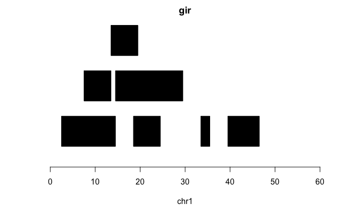

```r
plotGRanges(gir)
```

Resize each range to it’s +1 nucleotide. *Is strand specific!*

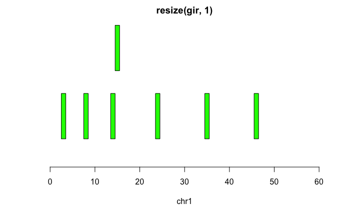

```r
plotGRanges(resize(gir,1), xlim=c(0,60), col="green")
```

We can make a plot of the “promoters” as the 3 bp upstream of the start sites.

[figure not shown]

```r
par(mfrow=c(2,1), mar=c(4,2,2,2))
plotGRanges(gir, xlim=c(0,60))
plotGRanges(flank(gir, 3), xlim=c(0,60), col='purple')
```

Or can get the flank at the end using `start=F` option in `flank`.

[figure not shown]

```r
par(mfrow=c(2,1), mar=c(4,2,2,2))
plotGRanges(gir, xlim=c(0,60))
plotGRanges(flank(gir, 2, start=F), xlim=c(0,60), col='brown')
```

## Finding Overlaps

Load the libraries and data for this section.

```r
library(GenomicFeatures)
library(GenomicRanges)
library(IRanges)
library(ph525x)
load("HepG2.rda")  # cell line of liver origin
load("GM12878.rda")  # immortalized B cell
```

Using `findOverlaps` to find overlaps between `GRange` objects.

```r
res <- findOverlaps(query = HepG2, subject = GM12878)
res
```

```
Hits object with 75 hits and 0 metadata columns:
       queryHits subjectHits
       <integer>   <integer>
   [1]         1          12
   [2]         2          78
   [3]         4         777
   [4]         5           8
   [5]         8          13
   ...       ...         ...
  [71]       285         621
  [72]       287         174
  [73]       291        1855
  [74]       294         512
  [75]       300         144
  -------
  queryLength: 303 / subjectLength: 1873
```

To get all of the “hits”, i.e. the ranges of the `query` that overlapped the `subject`, **must** use the function `queryHits` = cannot just subset `res`!

```r
index <- queryHits(res)
erbs <- HepG2[index, ]
erbs
```

```
GRanges object with 75 ranges and 7 metadata columns:
       seqnames              ranges strand |      name     score       col signalValue
          <Rle>           <IRanges>  <Rle> | <numeric> <integer> <logical>   <numeric>
   [1]     chr2   20335378-20335787      * |      <NA>         0      <NA>      58.251
   [2]    chr20       328285-329145      * |      <NA>         0      <NA>      10.808
   [3]    chr19     1244419-1245304      * |      <NA>         0      <NA>      12.427
   [4]    chr11   64071828-64073069      * |      <NA>         0      <NA>       10.85
   [5]     chr2   16938364-16938840      * |      <NA>         0      <NA>      12.783
   ...      ...                 ...    ... .       ...       ...       ...         ...
  [71]    chr12 118558730-118559158      * |      <NA>         0      <NA>       8.292
  [72]     chr1   35331750-35332300      * |      <NA>         0      <NA>      10.458
  [73]     chr1   26146200-26147004      * |      <NA>         0      <NA>       5.742
  [74]     chr6   44224657-44225693      * |      <NA>         0      <NA>       3.525
  [75]     chr1 110198573-110199126      * |      <NA>         0      <NA>       7.929
          pValue       qValue      peak
       <numeric>    <numeric> <integer>
   [1]    75.899 6.143712e-72       195
   [2]    69.685 5.028065e-66       321
   [3]    43.855 1.359756e-40       604
   [4]    40.977 7.333863e-38       492
   [5]    38.004 5.360291e-35       255
   ...       ...          ...       ...
  [71]    10.294 8.590894e-09       195
  [72]    10.233 9.818222e-09       341
  [73]    10.176 1.104291e-08       337
  [74]    10.102 1.296207e-08       838
  [75]    10.047 1.442076e-08       197
  -------
  seqinfo: 93 sequences (1 circular) from hg19 genome
```

To extract only the ranges (leaving the metadata behind):

```r
erbs <- granges(erbs)
erbs
```

```
GRanges object with 75 ranges and 0 metadata columns:
       seqnames              ranges strand
          <Rle>           <IRanges>  <Rle>
   [1]     chr2   20335378-20335787      *
   [2]    chr20       328285-329145      *
   [3]    chr19     1244419-1245304      *
   [4]    chr11   64071828-64073069      *
   [5]     chr2   16938364-16938840      *
   ...      ...                 ...    ...
  [71]    chr12 118558730-118559158      *
  [72]     chr1   35331750-35332300      *
  [73]     chr1   26146200-26147004      *
  [74]     chr6   44224657-44225693      *
  [75]     chr1 110198573-110199126      *
  -------
  seqinfo: 93 sequences (1 circular) from hg19 genome
```

## Finding Overlaps Assessment

1. Where does the 17th HepG2 region start?

```r
HepG2[17,]
```

```
GRanges object with 1 range and 7 metadata columns:
      seqnames            ranges strand |      name     score       col signalValue    pValue
         <Rle>         <IRanges>  <Rle> | <numeric> <integer> <logical>   <numeric> <numeric>
  [1]    chr22 46528596-46529164      * |      <NA>         0      <NA>      16.383     34.97
           qValue      peak
        <numeric> <integer>
  [1] 2.60856e-32       272
  -------
  seqinfo: 93 sequences (1 circular) from hg19 genome
```

2. Use `distanceToNearest` to find the closest region in GM12878 to the 17th region in HepG2. What is the start site of this region?

```r
nearest(HepG2[17,], GM12878) %>% GM12878[.,]
```

```
GRanges object with 1 range and 7 metadata columns:
      seqnames            ranges strand |      name     score       col signalValue    pValue
         <Rle>         <IRanges>  <Rle> | <numeric> <integer> <logical>   <numeric> <numeric>
  [1]    chr22 46524762-46526311      * |      1069         0      <NA>       10.72    25.301
         qValue      peak
      <numeric> <integer>
  [1]  2.026872      1056
  -------
  seqinfo: 93 sequences (1 circular) from hg19 genome
```

3. What is the distance between the 17th region of HepG2 and its closest region in GM12878?

```r
distanceToNearest(HepG2[17,], GM12878)
```

```
Hits object with 1 hit and 1 metadata column:
      queryHits subjectHits |  distance
      <integer>   <integer> | <integer>
  [1]         1         945 |      2284
  -------
  queryLength: 1 / subjectLength: 1873
```

4. For each region in HepG2 find the closest region in GM12878 and record the distance. What proportion of these distances are smaller than 2000 base pairs? Distance is a metadata column on the `Hits` object, so consider `mcols()`.

```r
dtn <- distanceToNearest(HepG2, GM12878) %>% mcols
sum(dtn$distance < 2000) / length(dtn$distance)
```

```
[1] 0.2673267
```

# Structure for general feature sets: SummarizedExperiment

## Introduction to the SummarizedExperiment container

`SummarizedExperiment` is meant as the successor for `ExpressionSet`. There are many methods written for it that can be found using the command `methods(class="SummarizedExperiment")`.

Example to illustrate how to use this container:

```r
library(airway)
data(airway)
airway
```

```
class: RangedSummarizedExperiment
dim: 64102 8
metadata(1): ''
assays(1): counts
rownames(64102): ENSG00000000003 ENSG00000000005 ... LRG_98 LRG_99
rowData names(0):
colnames(8): SRR1039508 SRR1039509 ... SRR1039520 SRR1039521
colData names(9): SampleName cell ... Sample BioSample
```

```r
assay(airway[1:4,1:5])
```

```
                SRR1039508 SRR1039509 SRR1039512 SRR1039513 SRR1039516
ENSG00000000003        679        448        873        408       1138
ENSG00000000005          0          0          0          0          0
ENSG00000000419        467        515        621        365        587
ENSG00000000457        260        211        263        164        245
```

```r
rowRanges(airway)
```

```
GRangesList object of length 64102:
$ENSG00000000003
GRanges object with 17 ranges and 2 metadata columns:
       seqnames            ranges strand |   exon_id       exon_name
          <Rle>         <IRanges>  <Rle> | <integer>     <character>
   [1]        X 99883667-99884983      - |    667145 ENSE00001459322
   [2]        X 99885756-99885863      - |    667146 ENSE00000868868
   [3]        X 99887482-99887565      - |    667147 ENSE00000401072
   [4]        X 99887538-99887565      - |    667148 ENSE00001849132
   [5]        X 99888402-99888536      - |    667149 ENSE00003554016
   ...      ...               ...    ... .       ...             ...
  [13]        X 99890555-99890743      - |    667156 ENSE00003512331
  [14]        X 99891188-99891686      - |    667158 ENSE00001886883
  [15]        X 99891605-99891803      - |    667159 ENSE00001855382
  [16]        X 99891790-99892101      - |    667160 ENSE00001863395
  [17]        X 99894942-99894988      - |    667161 ENSE00001828996

...
<64101 more elements>
-------
seqinfo: 722 sequences (1 circular) from an unspecified genome
```

## DataFrame and SummarizedExperiment assessment

1. The `erma` package includes detailed information on cell lines analyzed in the epigenomics road map project. You can query anatomic locations from which samples were derived as follows:

```r
library(erma)
ee = makeErmaSet()
class(colData(ee))
```

```
[1] "narrDF"
attr(,"package")
[1] "erma"
```

```r
length(names(colData(ee)))  # lots of attributes!
```

```
[1] 95
```

```r
table(ee$ANATOMY)
```

```
   BLOOD    BRAIN      ESC      FAT     IPSC    LIVER     LUNG     SKIN VASCULAR
      15        7        2        1        1        1        2        1        1
```

2. Use the ErmaSet instance generated in the previous problem. Consider the code

```r
mydf = colData(ee)[,1:10]
getClass("DataFrame")
```

```
Class "DataFrame" [package "S4Vectors"]

Slots:

Name:           rownames             nrows          listData       elementType
Class: character_OR_NULL           integer              list         character

Name:    elementMetadata          metadata
Class: DataTable_OR_NULL              list

Extends:
Class "DataTable", directly
Class "SimpleList", directly
Class "DataTable_OR_NULL", by class "DataTable", distance 2
Class "List", by class "SimpleList", distance 2
Class "Vector", by class "SimpleList", distance 3
Class "list_OR_List", by class "SimpleList", distance 3
Class "Annotated", by class "SimpleList", distance 4
```

```r
mydf$demomat = matrix(0, nrow=nrow(mydf), ncol=5)
dim(mydf$demomat)
```

```
[1] 31  5
```

```r
dim(mydf)
```

```
[1] 31 11
```

```r
dim(data.frame(mydf))
```

```
[1] 31 15
```

## Memory-sparing approaches with HDF5 and indexed files

### External HDF5

Use the “garbage collector” functoin`gc` to see memory usage in R.

The `HDF5Array` package to save RAM. Use `writeHDF5Array(var, filename, varname)` to save a variable `var` to a file `filename` as the variable `varname`. Then use `x <- HDF5Array(filename, varname)` to get a *reference* to the data. The function `saveHDF5SummarizedExperiment` can do the same process for a `SummarizedExperiment` object.

### GenomicFiles: application to many BAM files

The package `GenomicFiles` has functions for the parallel use of several files. This is especially useful with large data files.

### Multiple BED files: a slice of the epigenomics roadmap

Can handle this epigenomic data using the `erma` package.

### External data resources assessment

1. Let’s use the airway package again to obtain a SummarizedExperiment, saving it as HDF5 in a temporary location.

```r
library(airway)
library(HDF5Array)
td = tempfile()
saveHDF5SummarizedExperiment(airway, td)
```

After this save operation completes, what is

```r
length(dir(td))
```

```
[1] 2
```

2. Now issue the command

```r
X  = readRDS(dir(td, full=TRUE)[2])
```

What is the class of X?

```r
class(X)
```

```
[1] "RangedSummarizedExperiment"
attr(,"package")
[1] "SummarizedExperiment"
```

# Multi-omics solutions; role of cloud resources

## Collecting multiple molecular assay outputs on a set of samples

Can handle multi-omic data in the `MultiAssayExperiment` package from Bioconductor. Here is a [link](http://tinyurl.com/MAEOurls) to a Google Spreadsheet where a lab has created `MultiAssayExperiment` object for the TCGA projects.

```r
library(MultiAssayExperiment)
```